# Análisis de conglomerados

Clustering, perfiles penitenciarios y aprendizaje no supervisado

Autor/a

Noam López Villanes

Fecha de publicación

17 de mayo de 2026

## 1 Objetivo de la sesión

En esta sesión trabajaremos con una base de población penitenciaria para introducir el **análisis de conglomerados**. A diferencia de una regresión o una prueba de hipótesis, aquí no partimos de una variable dependiente. El objetivo es encontrar grupos de casos que se parezcan entre sí según ciertas características observadas.

1. Preparar variables para un análisis de clustering.
2. Distinguir variables numéricas, categóricas y mixtas.
3. Escalar variables para que sean comparables.
4. Aplicar k-means e interpretar centroides.
5. Comparar resultados con clustering jerárquico y DBSCAN.
6. Usar PAM con distancia de Gower para variables mixtas.
7. Traducir los clústeres en perfiles interpretables.

## 2 Preparación

Si ejecutas este documento por partes, corre primero los chunks de **Instalar paquetes**, **Activar paquetes** y **Ubicar archivos**. Los tres están ocultos en el redenrizado final, pero esos bloques crean los paquetes, funciones y rutas que usan los demás chunks.

## 3 Importar y conocer la base

¿Qué información trae la base de población penitenciaria?

```r
pope <- read_delim(
  archivo_pope,
  delim = ";",
  locale = locale(encoding = "Latin1"),
  show_col_types = FALSE
) |>
  clean_names() |>
  mutate(
    sexo = str_to_sentence(sexo),
    delito_generico = str_squish(delito_generico),
    delito_especifico = str_squish(delito_especifico),
    situacion_juridica = str_to_sentence(str_squish(situacion_juridica)),
    departamento = str_to_title(departamento),
    edad = as.numeric(edad),
    no_de_ingresos = as.numeric(no_de_ingresos)
  )

glimpse(pope)
```

```
Rows: 97,605
Columns: 17
$ id                   <dbl> 1, 2, 3, 4, 5, 6, 7, 8, 9, 10, 11, 12, 13, 14, 15…
$ no_de_ingresos       <dbl> 3, 1, 1, 1, 1, 1, 1, 3, 1, 1, 1, 1, 1, 2, 1, 1, 1…
$ delito_generico      <chr> "DELITOS CONTRA EL PATRIMONIO", "DELITOS CONTRA L…
$ delito_especifico    <chr> "ROBO AGRAVADO", "HOMICIDIO CALIFICADO - ASESINAT…
$ situacion_juridica   <chr> "Sentenciado", "Sentenciado", "Sentenciado", "Pro…
$ edad                 <dbl> 30, 28, 23, 38, 19, 43, 37, 39, 37, 31, 31, 21, 4…
$ sexo                 <chr> "Masculino", "Masculino", "Masculino", "Masculino…
$ pais                 <chr> "PERÚ", "PERÚ", "COLOMBIA", "PERÚ", "PERÚ", "PERÚ…
$ estado_civil         <chr> "SOLTERO", "SOLTERO", "CONVIVIENTE", "CONVIVIENTE…
$ grado_de_instruccion <chr> "PRIMARIA COMP.", "SECUNDARIA COMP.", "SECUNDARIA…
$ ocupacion_generico   <chr> "OFICIOS", "OFICIOS", "OFICIOS", "OFICIOS", "OFIC…
$ ocupacion_especifico <chr> "OBREROS", "OBREROS", "OTROS OFICIOS", "OBREROS",…
$ nombre_del_penal     <chr> "E.P. DE TUMBES", "E.P. DE TUMBES", "E.P. DE TUMB…
$ departamento         <chr> "Tumbes", "Tumbes", "Tumbes", "Tumbes", "Tumbes",…
$ oficina_regional     <chr> "Norte - Chiclayo", "Norte - Chiclayo", "Norte - …
$ mes                  <chr> "JUNIO", "JUNIO", "JUNIO", "JUNIO", "JUNIO", "JUN…
$ continente           <chr> "América", "América", "América", "América", "Amér…
```

La base registra personas privadas de libertad y contiene variables sociodemográficas, jurídicas y penitenciarias. Para clustering debemos elegir variables que tengan sentido sustantivo y que puedan compararse técnicamente.

¿Cuántos casos tenemos y qué rangos observamos?

```r
pope |>
  summarise(
    personas = n(),
    edad_minima = min(edad, na.rm = TRUE),
    edad_maxima = max(edad, na.rm = TRUE),
    maximo_ingresos = max(no_de_ingresos, na.rm = TRUE),
    delitos_genericos = n_distinct(delito_generico),
    penales = n_distinct(nombre_del_penal),
    departamentos = n_distinct(departamento)
  )
```

| personas | edad_minima | edad_maxima | maximo_ingresos | delitos_genericos | penales | departamentos |
| --- | --- | --- | --- | --- | --- | --- |
| 97605 | 18 | 95 | 21 | 25 | 69 | 25 |

Esta primera revisión ayuda a evitar errores de interpretación. Por ejemplo, edad y número de ingresos son numéricas, pero sexo, delito genérico y situación jurídica son categóricas.

## 4 Exploración inicial

¿Cómo se distribuye la edad de la población penitenciaria?

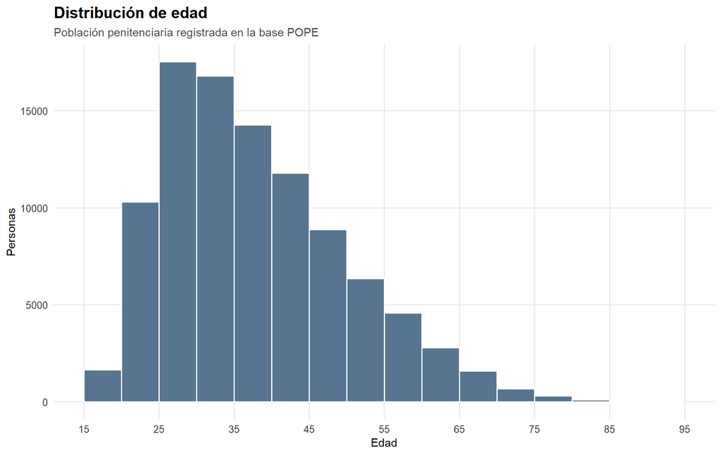

```r
pope |>
  ggplot(aes(x = edad)) +
  geom_histogram(binwidth = 5, fill = "#577590", color = "white", boundary = 0) +
  scale_x_continuous(breaks = seq(15, 100, by = 10)) +
  labs(
    title = "Distribución de edad",
    subtitle = "Población penitenciaria registrada en la base POPE",
    x = "Edad",
    y = "Personas"
  ) +
  tema_sesion()
```

La edad es una variable numérica de razón. En clustering, una variable numérica con escala amplia puede dominar el cálculo de distancias si no la estandarizamos.

¿Qué delitos genéricos son más frecuentes?

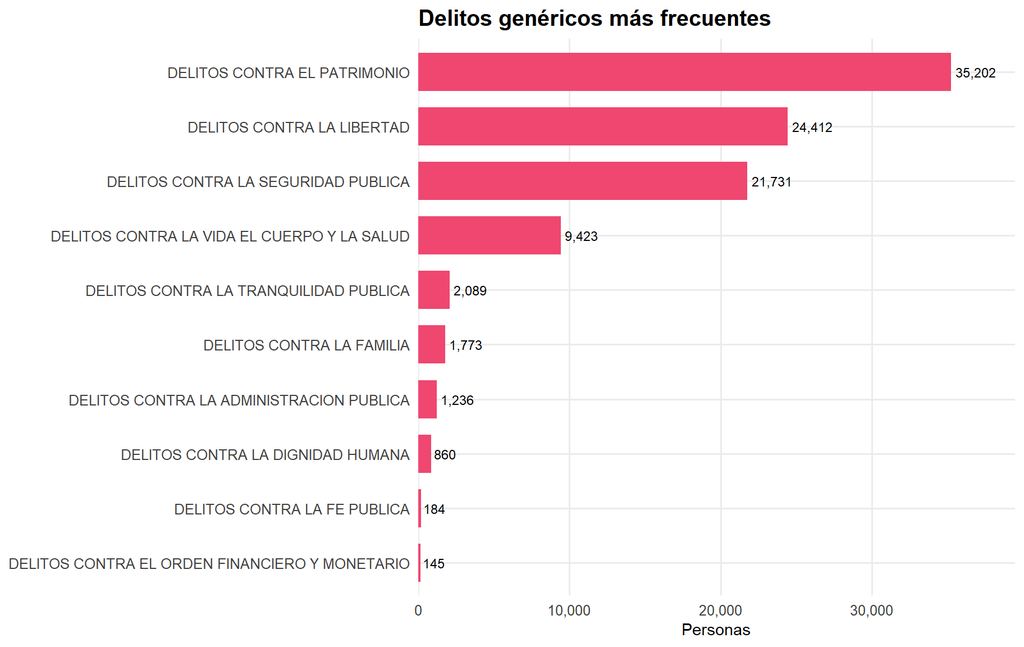

```r
pope |>
  count(delito_generico, sort = TRUE) |>
  slice_head(n = 10) |>
  ggplot(aes(x = n, y = reorder(delito_generico, n))) +
  geom_col(fill = "#ef476f", width = 0.7) +
  geom_text(aes(label = comma(n)), hjust = -0.12, size = 3.2) +
  scale_x_continuous(labels = comma_format(), expand = expansion(mult = c(0, 0.12))) +
  labs(
    title = "Delitos genéricos más frecuentes",
    x = "Personas",
    y = NULL
  ) +
  tema_sesion()
```

Las categorías más frecuentes son relevantes porque pueden aparecer como rasgos distintivos de algunos clústeres. Sin embargo, no conviene meter demasiadas categorías raras en una primera versión del ejercicio.

¿Cómo se relacionan edad y número de ingresos?

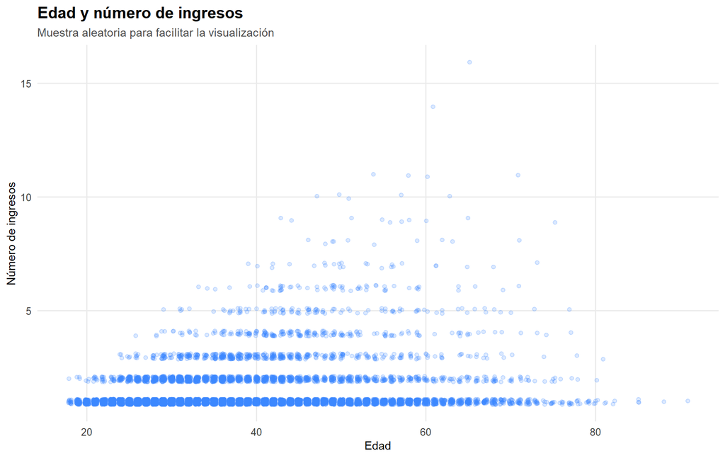

```r
set.seed(123)
pope_muestra <- pope |>
  filter(!is.na(edad), !is.na(no_de_ingresos)) |>
  slice_sample(n = min(10000, nrow(pope |> filter(!is.na(edad), !is.na(no_de_ingresos)))))

pope_muestra |>
  ggplot(aes(x = edad, y = no_de_ingresos)) +
  geom_jitter(alpha = 0.18, width = 0.25, height = 0.12, color = "#3a86ff") +
  scale_y_continuous(breaks = pretty_breaks()) +
  labs(
    title = "Edad y número de ingresos",
    subtitle = "Muestra aleatoria para facilitar la visualización",
    x = "Edad",
    y = "Número de ingresos"
  ) +
  tema_sesion()
```

Esta relación es útil para introducir la idea de distancia: dos personas pueden parecerse porque tienen edad e historial de ingresos similares, aunque sus delitos o situación jurídica sean distintos.

## 5 Preparar variables para clustering

¿Por qué debemos escalar las variables numéricas?

```r
datos_cluster <- pope |>
  transmute(
    id,
    edad,
    ingresos = no_de_ingresos,
    sexo,
    delito_generico,
    situacion_juridica,
    departamento,
    nombre_del_penal
  ) |>
  filter(
    !is.na(edad),
    !is.na(ingresos),
    edad >= 18,
    ingresos >= 1
  )

variables_numericas <- datos_cluster |>
  select(edad, ingresos)

variables_escaladas <- variables_numericas |>
  scale() |>
  as_tibble()

summary(variables_numericas)
```

```
      edad          ingresos
 Min.   :18.00   Min.   : 1.000
 1st Qu.:29.00   1st Qu.: 1.000
 Median :36.00   Median : 1.000
 Mean   :38.48   Mean   : 1.414
 3rd Qu.:46.00   3rd Qu.: 1.000
 Max.   :95.00   Max.   :21.000
```

```r
summary(variables_escaladas)
```

```
      edad            ingresos
 Min.   :-1.7014   Min.   :-0.42
 1st Qu.:-0.7876   1st Qu.:-0.42
 Median :-0.2061   Median :-0.42
 Mean   : 0.0000   Mean   : 0.00
 3rd Qu.: 0.6246   3rd Qu.:-0.42
 Max.   : 4.6953   Max.   :19.86
```

Escalar significa restar la media y dividir entre la desviación estándar. Después de escalar, edad e ingresos quedan en unidades comparables. Esto es clave para métodos como k-means, que usan distancias.

## 6 Elegir el número de clústeres

¿Cuántos grupos deberíamos buscar?

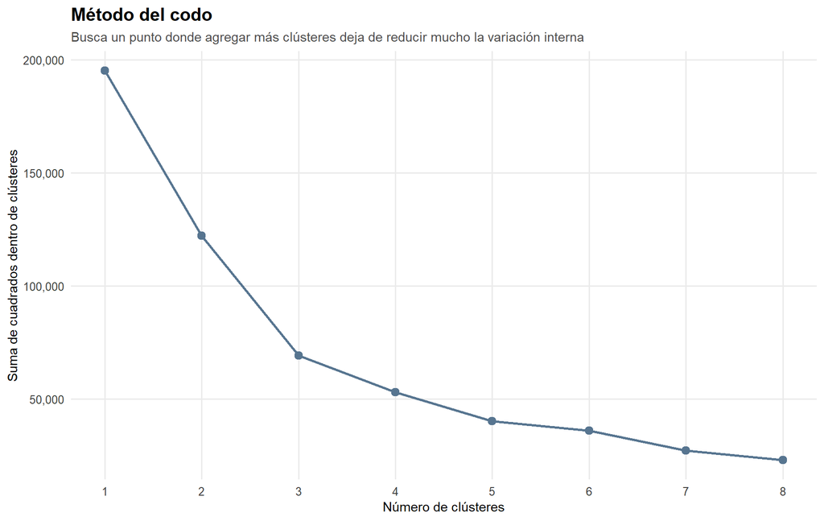

```r
set.seed(123)
k_posibles <- 1:8

suma_cuadrados <- map_dfr(k_posibles, function(k) {
  modelo <- kmeans(variables_escaladas, centers = k, nstart = 20)
  tibble(k = k, wss = modelo$tot.withinss)
})

suma_cuadrados |>
  ggplot(aes(x = k, y = wss)) +
  geom_line(color = "#577590", linewidth = 0.9) +
  geom_point(size = 2.8, color = "#577590") +
  scale_x_continuous(breaks = k_posibles) +
  scale_y_continuous(labels = comma_format()) +
  labs(
    title = "Método del codo",
    subtitle = "Busca un punto donde agregar más clústeres deja de reducir mucho la variación interna",
    x = "Número de clústeres",
    y = "Suma de cuadrados dentro de clústeres"
  ) +
  tema_sesion()
```

El método del codo no da una respuesta automática. Ayuda a justificar una decisión. En clase usaremos `k = 4` porque permite diferenciar perfiles sin volver la interpretación demasiado fragmentada.

## 7 K-means

¿Qué perfiles aparecen si agrupamos por edad e ingresos?

```r
set.seed(123)
modelo_kmeans <- kmeans(variables_escaladas, centers = 4, nstart = 25)

datos_kmeans <- datos_cluster |>
  mutate(cluster_kmeans = factor(modelo_kmeans$cluster))

datos_kmeans |>
  group_by(cluster_kmeans) |>
  summarise(
    personas = n(),
    porcentaje = personas / nrow(datos_kmeans),
    edad_promedio = mean(edad, na.rm = TRUE),
    ingresos_promedio = mean(ingresos, na.rm = TRUE),
    .groups = "drop"
  )
```

| cluster_kmeans | personas | porcentaje | edad_promedio | ingresos_promedio |
| --- | --- | --- | --- | --- |
| 1 | 54657 | 0.55998156 | 30.36647 | 1.088333 |
| 2 | 1980 | 0.02028585 | 50.51010 | 6.243434 |
| 3 | 14014 | 0.14357871 | 40.84958 | 2.592978 |
| 4 | 26954 | 0.27615389 | 52.82029 | 1.107628 |

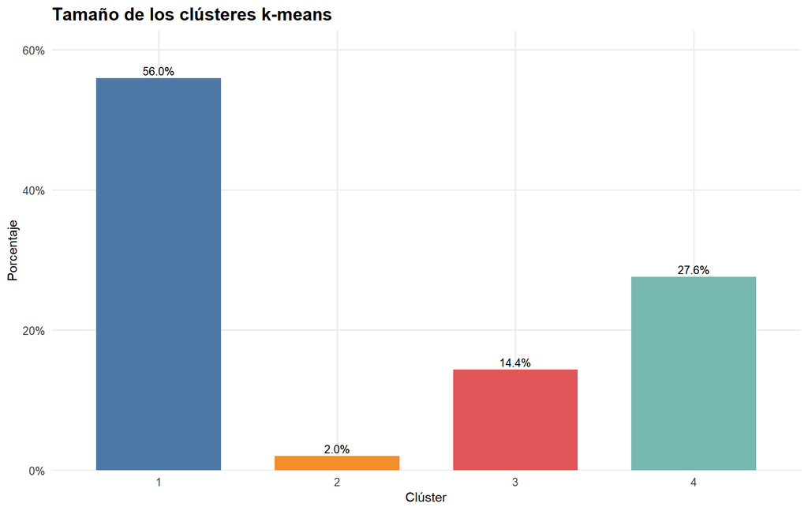

```r
datos_kmeans |>
  count(cluster_kmeans) |>
  mutate(porcentaje = n / sum(n)) |>
  ggplot(aes(x = cluster_kmeans, y = porcentaje, fill = cluster_kmeans)) +
  geom_col(width = 0.7, show.legend = FALSE) +
  geom_text(aes(label = percent(porcentaje, accuracy = 0.1)), vjust = -0.35, size = 3.4) +
  scale_y_continuous(labels = percent_format(), expand = expansion(mult = c(0, 0.12))) +
  scale_fill_paletteer_d("ggthemes::Tableau_10") +
  labs(
    title = "Tamaño de los clústeres k-means",
    x = "Clúster",
    y = "Porcentaje"
  ) +
  tema_sesion()
```

El tamaño de cada clúster nos dice si el modelo está produciendo grupos relativamente equilibrados o si separa casos muy específicos.

¿Dónde se ubican los clústeres en el espacio edad-ingresos?

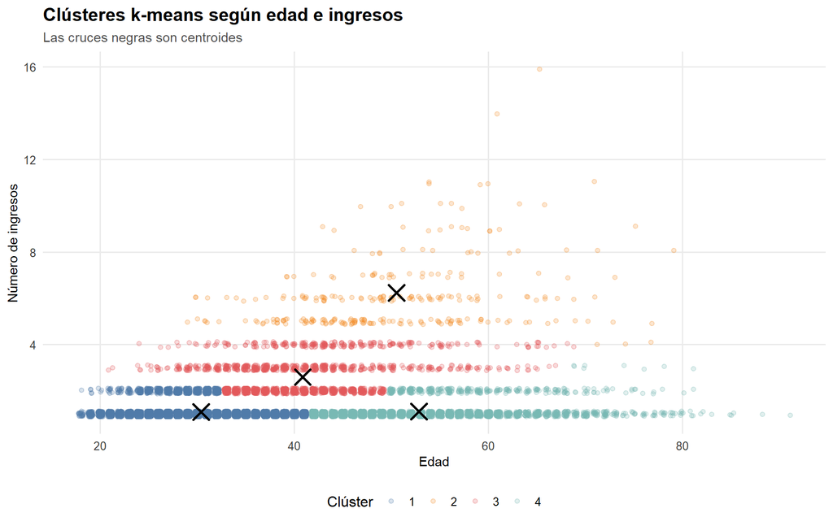

```r
centroides <- datos_kmeans |>
  group_by(cluster_kmeans) |>
  summarise(
    edad = mean(edad, na.rm = TRUE),
    ingresos = mean(ingresos, na.rm = TRUE),
    .groups = "drop"
  )

datos_kmeans |>
  slice_sample(n = min(12000, nrow(datos_kmeans))) |>
  ggplot(aes(x = edad, y = ingresos, color = cluster_kmeans)) +
  geom_jitter(alpha = 0.22, width = 0.25, height = 0.12) +
  geom_point(
    data = centroides,
    aes(x = edad, y = ingresos),
    inherit.aes = FALSE,
    shape = 4,
    stroke = 1.4,
    size = 5,
    color = "black"
  ) +
  scale_color_paletteer_d("ggthemes::Tableau_10") +
  labs(
    title = "Clústeres k-means según edad e ingresos",
    subtitle = "Las cruces negras son centroides",
    x = "Edad",
    y = "Número de ingresos",
    color = "Clúster"
  ) +
  tema_sesion()
```

Los centroides muestran el promedio de edad e ingresos dentro de cada grupo. Esa comparación permite describir los perfiles con más precisión que el gráfico de dispersión por sí solo.

¿Cómo podemos describir cada clúster?

```r
perfil_kmeans <- datos_kmeans |>
  group_by(cluster_kmeans) |>
  summarise(
    personas = n(),
    edad_promedio = mean(edad, na.rm = TRUE),
    ingresos_promedio = mean(ingresos, na.rm = TRUE),
    porcentaje_mujeres = mean(sexo == "Femenino", na.rm = TRUE),
    delito_mas_frecuente = names(sort(table(delito_generico), decreasing = TRUE))[1],
    situacion_mas_frecuente = names(sort(table(situacion_juridica), decreasing = TRUE))[1],
    .groups = "drop"
  ) |>
  mutate(
    porcentaje_mujeres = percent(porcentaje_mujeres, accuracy = 0.1)
  )

perfil_kmeans
```

| cluster_kmeans | personas | edad_promedio | ingresos_promedio | porcentaje_mujeres | delito_mas_frecuente | situacion_mas_frecuente |
| --- | --- | --- | --- | --- | --- | --- |
| 1 | 54657 | 30.36647 | 1.088333 | 5.5% | DELITOS CONTRA EL PATRIMONIO | Sentenciado |
| 2 | 1980 | 50.51010 | 6.243434 | 2.5% | DELITOS CONTRA EL PATRIMONIO | Sentenciado |
| 3 | 14014 | 40.84958 | 2.592978 | 2.9% | DELITOS CONTRA EL PATRIMONIO | Sentenciado |
| 4 | 26954 | 52.82029 | 1.107628 | 6.0% | DELITOS CONTRA LA LIBERTAD | Sentenciado |

Esta tabla convierte el resultado técnico en perfiles interpretables. Un clúster puede representar personas jóvenes con pocos ingresos, personas mayores con varios ingresos, u otros patrones según los datos.

```r
write_csv(
  datos_kmeans,
  file.path(ruta_resultados, "pope_clusters_kmeans.csv")
)
```

## 8 Clustering jerárquico

¿Qué pasa si no fijamos centroides sino que unimos casos por similitud?

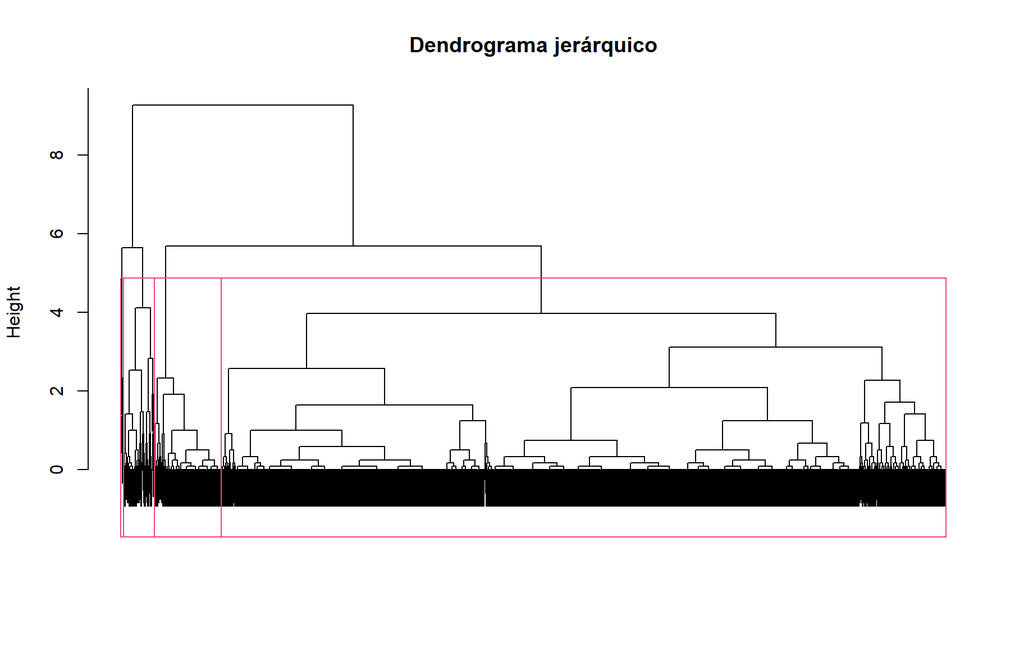

```r
set.seed(123)
muestra_hc <- datos_cluster |>
  slice_sample(n = min(1200, nrow(datos_cluster)))

variables_hc <- muestra_hc |>
  select(edad, ingresos) |>
  scale()

distancia_hc <- dist(variables_hc)
modelo_hc <- hclust(distancia_hc, method = "complete")

plot(
  modelo_hc,
  labels = FALSE,
  main = "Dendrograma jerárquico",
  xlab = "",
  sub = ""
)
rect.hclust(modelo_hc, k = 4, border = "#ef476f")
```

El dendrograma muestra un proceso de agrupamiento. Al cortar el árbol en cuatro ramas, obtenemos cuatro grupos. La ventaja es que permite ver anidamientos; la desventaja es que puede volverse pesado con bases grandes.

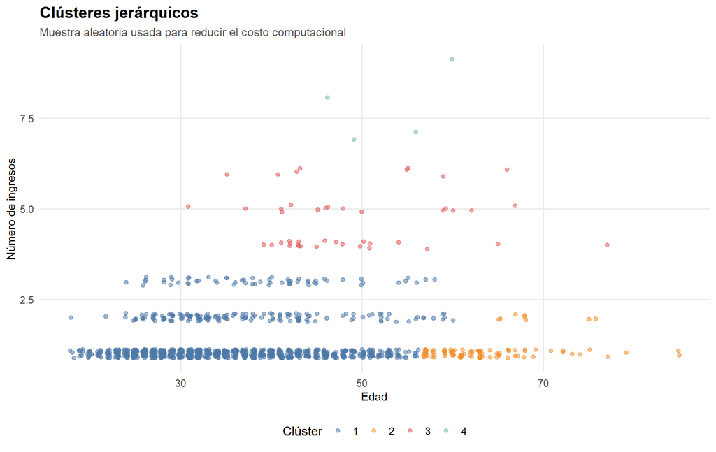

```r
muestra_hc <- muestra_hc |>
  mutate(cluster_hc = factor(cutree(modelo_hc, k = 4)))

muestra_hc |>
  ggplot(aes(x = edad, y = ingresos, color = cluster_hc)) +
  geom_jitter(alpha = 0.5, width = 0.25, height = 0.12) +
  scale_color_paletteer_d("ggthemes::Tableau_10") +
  labs(
    title = "Clústeres jerárquicos",
    subtitle = "Muestra aleatoria usada para reducir el costo computacional",
    x = "Edad",
    y = "Número de ingresos",
    color = "Clúster"
  ) +
  tema_sesion()
```

Este método sirve para discutir que no hay una única forma correcta de agrupar. Cada algoritmo define la similitud de manera distinta.

## 9 DBSCAN

¿Podemos identificar grupos densos y casos atípicos?

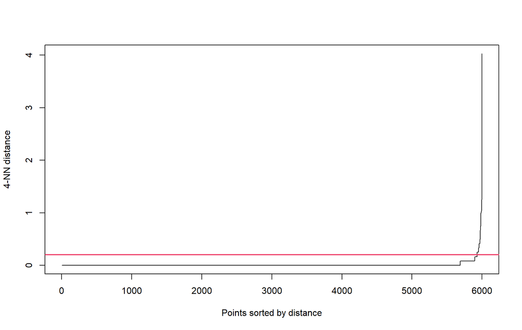

```r
set.seed(123)
muestra_dbscan <- datos_cluster |>
  slice_sample(n = min(6000, nrow(datos_cluster)))

variables_dbscan <- muestra_dbscan |>
  select(edad, ingresos) |>
  scale()

kNNdistplot(variables_dbscan, k = 4)
abline(h = 0.20, col = "#ef476f", lwd = 2)
```

El gráfico ordena las distancias al cuarto vecino más cercano. El tramo donde la curva empieza a subir con más fuerza sirve como referencia para escoger `eps`; aquí usamos `0.20` como valor inicial para discutir cuántos casos quedan como ruido y cuántos forman clústeres.

```r
modelo_dbscan <- dbscan(variables_dbscan, eps = 0.20, minPts = 5)

muestra_dbscan <- muestra_dbscan |>
  mutate(
    cluster_dbscan = factor(
      modelo_dbscan$cluster,
      levels = sort(unique(modelo_dbscan$cluster))
    )
  )

muestra_dbscan |>
  count(cluster_dbscan) |>
  mutate(
    tipo = if_else(cluster_dbscan == "0", "Ruido", "Clúster"),
    porcentaje = n / sum(n)
  )
```

| cluster_dbscan | n | tipo | porcentaje |
| --- | --- | --- | --- |
| 0 | 53 | Ruido | 0.0088333333 |
| 1 | 4497 | Clúster | 0.7495000000 |
| 2 | 944 | Clúster | 0.1573333333 |
| 3 | 289 | Clúster | 0.0481666667 |
| 4 | 7 | Clúster | 0.0011666667 |
| 5 | 21 | Clúster | 0.0035000000 |
| 6 | 110 | Clúster | 0.0183333333 |
| 7 | 44 | Clúster | 0.0073333333 |
| 8 | 17 | Clúster | 0.0028333333 |
| 9 | 13 | Clúster | 0.0021666667 |

[output cut: 1 more lines]

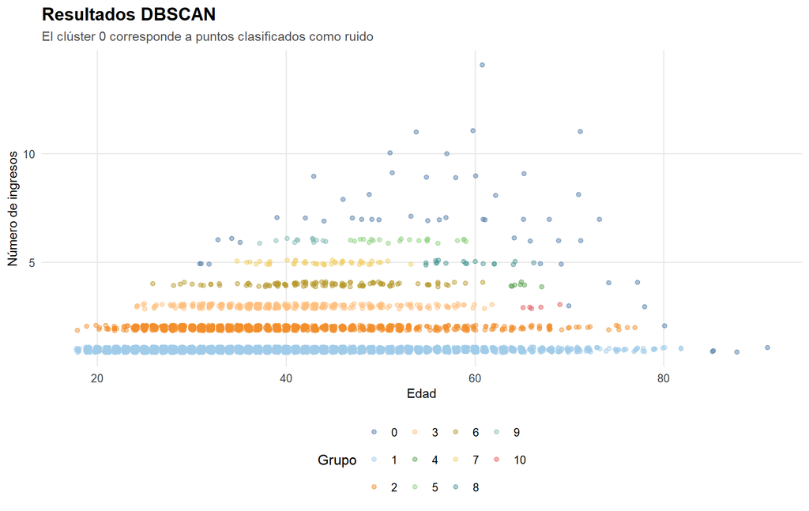

```r
muestra_dbscan |>
  ggplot(aes(x = edad, y = ingresos, color = cluster_dbscan)) +
  geom_jitter(alpha = 0.45, width = 0.25, height = 0.12) +
  scale_color_paletteer_d("ggthemes::Tableau_20") +
  labs(
    title = "Resultados DBSCAN",
    subtitle = "El clúster 0 corresponde a puntos clasificados como ruido",
    x = "Edad",
    y = "Número de ingresos",
    color = "Grupo"
  ) +
  tema_sesion()
```

DBSCAN es útil cuando esperamos grupos por densidad y casos atípicos. En cambio, k-means fuerza a que todos los casos pertenezcan a algún clúster.

## 10 PAM con variables mixtas

¿Qué hacemos si queremos combinar variables numéricas y categóricas?

```r
set.seed(123)
muestra_pam <- datos_cluster |>
  mutate(
    sexo = factor(sexo),
    delito_generico = fct_lump_n(factor(delito_generico), n = 6),
    situacion_juridica = factor(situacion_juridica)
  ) |>
  slice_sample(n = min(2500, nrow(datos_cluster))) |>
  select(edad, ingresos, sexo, delito_generico, situacion_juridica)

distancia_gower <- daisy(muestra_pam, metric = "gower")
modelo_pam <- pam(distancia_gower, k = 4)

datos_pam <- muestra_pam |>
  mutate(cluster_pam = factor(modelo_pam$clustering))

tibble(
  cluster_pam = factor(seq_along(modelo_pam$id.med)),
  observacion_medoide = modelo_pam$id.med,
  personas = as.integer(modelo_pam$clusinfo[, "size"]),
  diametro = modelo_pam$clusinfo[, "diameter"],
  separacion = modelo_pam$clusinfo[, "separation"]
)
```

| cluster_pam | observacion_medoide | personas | diametro | separacion |
| --- | --- | --- | --- | --- |
| 1 | 72 | 662 | 0.8071918 | 0.002739726 |
| 2 | 375 | 440 | 0.8575342 | 0.002739726 |
| 3 | 123 | 661 | 0.6684932 | 0.002739726 |
| 4 | 124 | 737 | 0.6349315 | 0.002739726 |

La distancia de Gower permite combinar variables numéricas y categóricas. Por eso PAM es una buena alternativa cuando el perfil no depende solo de edad e ingresos.

```r
perfil_pam <- datos_pam |>
  group_by(cluster_pam) |>
  summarise(
    personas = n(),
    edad_promedio = mean(edad, na.rm = TRUE),
    ingresos_promedio = mean(ingresos, na.rm = TRUE),
    sexo_mas_frecuente = names(sort(table(sexo), decreasing = TRUE))[1],
    delito_mas_frecuente = names(sort(table(delito_generico), decreasing = TRUE))[1],
    situacion_mas_frecuente = names(sort(table(situacion_juridica), decreasing = TRUE))[1],
    .groups = "drop"
  )

perfil_pam
```

| cluster_pam | personas | edad_promedio | ingresos_promedio | sexo_mas_frecuente | delito_mas_frecuente | situacion_mas_frecuente |
| --- | --- | --- | --- | --- | --- | --- |
| 1 | 662 | 47.97583 | 1.246224 | Masculino | DELITOS CONTRA LA LIBERTAD | Sentenciado |
| 2 | 440 | 42.13636 | 1.486364 | Masculino | DELITOS CONTRA LA SEGURIDAD PUBLICA | Sentenciado |
| 3 | 661 | 34.55371 | 1.642965 | Masculino | DELITOS CONTRA EL PATRIMONIO | Sentenciado |
| 4 | 737 | 31.86431 | 1.369064 | Masculino | DELITOS CONTRA EL PATRIMONIO | Procesado |

La tabla permite leer cada clúster como un perfil: combina edad, ingresos, sexo, delito y situación jurídica. Conviene nombrar los grupos a partir de esos rasgos dominantes y revisar si las diferencias son claras antes de usar los perfiles en una interpretación sustantiva.

## 11 Comparar métodos

¿Qué método usaríamos según la pregunta?

| Método | Tipo de variables | Pregunta que responde mejor | Cuidado principal |
| --- | --- | --- | --- |
| K-means | Numéricas escaladas | ¿Qué grupos aparecen si todos los casos deben pertenecer a un clúster? | Requiere elegir `k`; sensible a escala y valores atípicos. |
| Jerárquico | Numéricas escaladas o distancias | ¿Cómo se van uniendo los casos según similitud? | Costoso con bases grandes; depende del método de enlace. |
| DBSCAN | Numéricas escaladas | ¿Hay zonas densas y casos de ruido? | Sensible a `eps` y `minPts`. |
| PAM + Gower | Variables mixtas | ¿Qué perfiles aparecen usando numéricas y categóricas? | Puede ser costoso; conviene trabajar con muestras o bases medianas. |

La elección del método depende de la pregunta, el tipo de variables, el tamaño de la base y la facilidad para explicar los resultados a una audiencia no técnica.

## 12 Ejercicios para seguir practicando

1. Repite k-means con `k = 3` y `k = 5`. ¿Cambian mucho los perfiles?
2. Incluye otra variable numérica o transforma edad en grupos. ¿Qué se gana y qué se pierde?
3. Cambia el valor de `eps` en DBSCAN y observa cuántos casos pasan a ruido.
4. Usa PAM con otro conjunto de variables categóricas.
5. Exporta la base con clústeres y calcula qué delitos predominan en cada grupo.

Estos ejercicios pueden apoyarse en el Posit Assistant de RStudio para revisar errores, pedir explicaciones de funciones y proponer mejoras al código.